# Risk Factor Analysis

## Outcome Variable

**Outcome Variable:** pers_wasted624

## Predictor Variables

**Intervention Variable:** ever_wasted06

**Adjustment Set:**

- sex
- arm
- enstunt
- month
- brthmon
- vagbrth
- single
- W_gagebrth
- W_birthwt
- W_birthlen
- W_mage
- W_mhtcm
- W_meducyrs
- W_feducyrs
- W_parity
- delta_month
- delta_brthmon
- delta_vagbrth
- delta_single
- delta_W_gagebrth
- delta_W_birthwt
- delta_W_birthlen
- delta_W_mage
- delta_W_mhtcm
- delta_W_meducyrs
- delta_W_feducyrs
- delta_W_parity

## Stratifying Variables

The analysis was stratified on these variable(s):

- studyid
- country

## Data Summary

| studyid | country | ever_wasted06 | pers_wasted624 | n_cell | n |
| --- | --- | --- | --- | --- | --- |
| ki0047075b-MAL-ED | BANGLADESH | 0 | 0 | 180 | 240 |
| ki0047075b-MAL-ED | BANGLADESH | 0 | 1 | 5 | 240 |
| ki0047075b-MAL-ED | BANGLADESH | 1 | 0 | 42 | 240 |
| ki0047075b-MAL-ED | BANGLADESH | 1 | 1 | 13 | 240 |
| ki0047075b-MAL-ED | BRAZIL | 0 | 0 | 192 | 207 |
| ki0047075b-MAL-ED | BRAZIL | 0 | 1 | 1 | 207 |
| ki0047075b-MAL-ED | BRAZIL | 1 | 0 | 13 | 207 |
| ki0047075b-MAL-ED | BRAZIL | 1 | 1 | 1 | 207 |
| ki0047075b-MAL-ED | INDIA | 0 | 0 | 153 | 235 |
| ki0047075b-MAL-ED | INDIA | 0 | 1 | 6 | 235 |
| ki0047075b-MAL-ED | INDIA | 1 | 0 | 54 | 235 |
| ki0047075b-MAL-ED | INDIA | 1 | 1 | 22 | 235 |
| ki0047075b-MAL-ED | NEPAL | 0 | 0 | 193 | 235 |
| ki0047075b-MAL-ED | NEPAL | 0 | 1 | 0 | 235 |
| ki0047075b-MAL-ED | NEPAL | 1 | 0 | 40 | 235 |
| ki0047075b-MAL-ED | NEPAL | 1 | 1 | 2 | 235 |
| ki0047075b-MAL-ED | PERU | 0 | 0 | 258 | 270 |
| ki0047075b-MAL-ED | PERU | 0 | 1 | 2 | 270 |
| ki0047075b-MAL-ED | PERU | 1 | 0 | 10 | 270 |
| ki0047075b-MAL-ED | PERU | 1 | 1 | 0 | 270 |
| ki0047075b-MAL-ED | SOUTH AFRICA | 0 | 0 | 232 | 259 |
| ki0047075b-MAL-ED | SOUTH AFRICA | 0 | 1 | 0 | 259 |
| ki0047075b-MAL-ED | SOUTH AFRICA | 1 | 0 | 25 | 259 |
| ki0047075b-MAL-ED | SOUTH AFRICA | 1 | 1 | 2 | 259 |
| ki0047075b-MAL-ED | TANZANIA, UNITED REPUBLIC OF | 0 | 0 | 233 | 245 |
| ki0047075b-MAL-ED | TANZANIA, UNITED REPUBLIC OF | 0 | 1 | 0 | 245 |
| ki0047075b-MAL-ED | TANZANIA, UNITED REPUBLIC OF | 1 | 0 | 12 | 245 |
| ki0047075b-MAL-ED | TANZANIA, UNITED REPUBLIC OF | 1 | 1 | 0 | 245 |
| ki1000108-CMC-V-BCS-2002 | INDIA | 0 | 0 | 174 | 370 |
| ki1000108-CMC-V-BCS-2002 | INDIA | 0 | 1 | 3 | 370 |

[output cut: 102 more lines]

The following strata were considered:

- studyid: ki0047075b-MAL-ED, country: BANGLADESH
- studyid: ki0047075b-MAL-ED, country: BRAZIL
- studyid: ki0047075b-MAL-ED, country: INDIA
- studyid: ki0047075b-MAL-ED, country: NEPAL
- studyid: ki0047075b-MAL-ED, country: PERU
- studyid: ki0047075b-MAL-ED, country: SOUTH AFRICA
- studyid: ki0047075b-MAL-ED, country: TANZANIA, UNITED REPUBLIC OF
- studyid: ki1000108-CMC-V-BCS-2002, country: INDIA
- studyid: ki1000108-IRC, country: INDIA
- studyid: ki1000109-EE, country: PAKISTAN
- studyid: ki1000109-ResPak, country: PAKISTAN
- studyid: ki1000304b-SAS-CompFeed, country: INDIA
- studyid: ki1000304b-SAS-FoodSuppl, country: INDIA
- studyid: ki1017093-NIH-Birth, country: BANGLADESH
- studyid: ki1017093b-PROVIDE, country: BANGLADESH
- studyid: ki1017093c-NIH-Crypto, country: BANGLADESH
- studyid: ki1066203-TanzaniaChild2, country: TANZANIA, UNITED REPUBLIC OF
- studyid: ki1101329-Keneba, country: GAMBIA
- studyid: ki1112895-Guatemala BSC, country: GUATEMALA
- studyid: ki1113344-GMS-Nepal, country: NEPAL
- studyid: ki1114097-CMIN, country: BANGLADESH
- studyid: ki1114097-CMIN, country: BRAZIL
- studyid: ki1114097-CMIN, country: GUINEA-BISSAU
- studyid: ki1114097-CMIN, country: PERU
- studyid: ki1114097-CONTENT, country: PERU
- studyid: ki1119695-PROBIT, country: BELARUS
- studyid: ki1126311-ZVITAMBO, country: ZIMBABWE
- studyid: ki1135781-COHORTS, country: GUATEMALA
- studyid: ki1135781-COHORTS, country: INDIA
- studyid: ki1135781-COHORTS, country: PHILIPPINES
- studyid: ki1148112-LCNI-5, country: MALAWI
- studyid: kiGH5241-JiVitA-3, country: BANGLADESH
- studyid: kiGH5241-JiVitA-4, country: BANGLADESH

### Dropped Strata

Some strata were dropped due to rare outcomes:

- studyid: ki0047075b-MAL-ED, country: BRAZIL
- studyid: ki0047075b-MAL-ED, country: NEPAL
- studyid: ki0047075b-MAL-ED, country: PERU
- studyid: ki0047075b-MAL-ED, country: SOUTH AFRICA
- studyid: ki0047075b-MAL-ED, country: TANZANIA, UNITED REPUBLIC OF
- studyid: ki1000108-CMC-V-BCS-2002, country: INDIA
- studyid: ki1112895-Guatemala BSC, country: GUATEMALA
- studyid: ki1114097-CMIN, country: BRAZIL
- studyid: ki1114097-CMIN, country: PERU
- studyid: ki1114097-CONTENT, country: PERU
- studyid: ki1119695-PROBIT, country: BELARUS

## Methods Detail

We’re interested in the causal parameters $E[Y_a]$ for all values of $a \in \mathcal{A}$. These parameters represent the mean outcome if, possibly contrary to fact, we intervened to set all units to have $A=a$. Under the randomization and positivity assumptions, these are identified by the statistical parameters $\psi_a=E_W[E_{Y|A,W}(Y|A=a,W)]$. In addition, we’re interested in the mean of $Y$, $E[Y]$ under no intervention (the observed mean). We will estimate these parameters by using SuperLearner to fit the relevant likelihood factors – $E_{Y|A,W}(Y|A=a,W)$ and $p(A=a|W)$, and then updating our likelihood fit using a joint TMLE.

For unadjusted analyses ($W=\{\}$), initial likelihoods were estimated using Lrnr_glm to estimate the simple $E(Y|A)$ and Lrnr_mean to estimate $p(A)$. For adjusted analyses, a small library containing Lrnr_glmnet, Lrnr_xgboost, and Lrnr_mean was used.

Having estimated these parameters, we will then use the delta method to estimate relative risks and attributable risks relative to a prespecified baseline level of $A$.

# Results Detail

## Results Plots

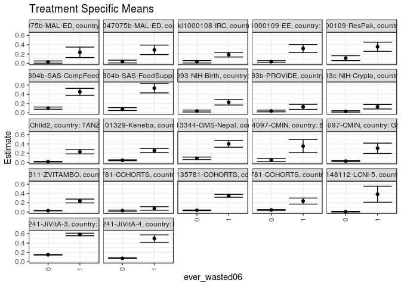

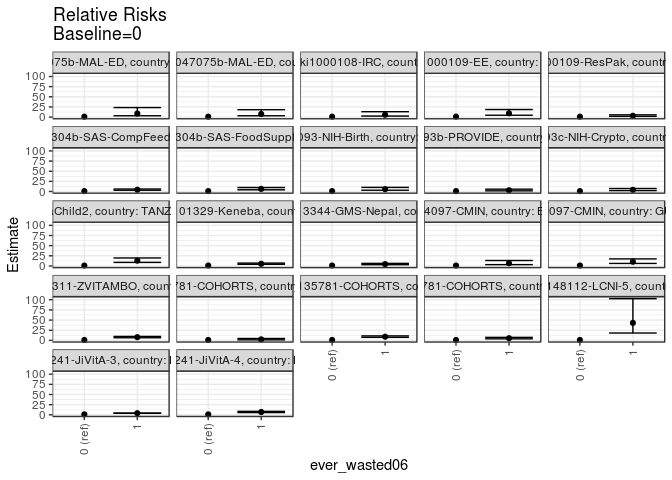

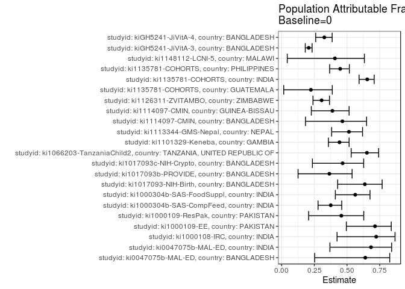

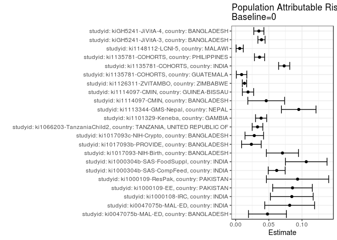

## Results Table

### Parameter: TSM

| studyid | country | intervention_level | baseline_level | estimate | ci_lower | ci_upper |
| --- | --- | --- | --- | --- | --- | --- |
| ki0047075b-MAL-ED | BANGLADESH | 0 | NA | 0.0270270 | 0.0036107 | 0.0504433 |
| ki0047075b-MAL-ED | BANGLADESH | 1 | NA | 0.2363636 | 0.1238495 | 0.3488778 |
| ki0047075b-MAL-ED | INDIA | 0 | NA | 0.0377358 | 0.0080534 | 0.0674183 |
| ki0047075b-MAL-ED | INDIA | 1 | NA | 0.2894737 | 0.1872946 | 0.3916527 |
| ki1000108-IRC | INDIA | 0 | NA | 0.0324324 | 0.0068747 | 0.0579902 |
| ki1000108-IRC | INDIA | 1 | NA | 0.1866667 | 0.1356920 | 0.2376414 |
| ki1000109-EE | PAKISTAN | 0 | NA | 0.0343511 | 0.0122682 | 0.0564341 |
| ki1000109-EE | PAKISTAN | 1 | NA | 0.3185841 | 0.2325626 | 0.4046055 |
| ki1000109-ResPak | PAKISTAN | 0 | NA | 0.1110436 | 0.0587422 | 0.1633450 |
| ki1000109-ResPak | PAKISTAN | 1 | NA | 0.3563219 | 0.2574775 | 0.4551664 |
| ki1000304b-SAS-CompFeed | INDIA | 0 | NA | 0.1028812 | 0.0792367 | 0.1265257 |
| ki1000304b-SAS-CompFeed | INDIA | 1 | NA | 0.4531347 | 0.3777765 | 0.5284929 |
| ki1000304b-SAS-FoodSuppl | INDIA | 0 | NA | 0.0826670 | 0.0516425 | 0.1136915 |
| ki1000304b-SAS-FoodSuppl | INDIA | 1 | NA | 0.5324361 | 0.4302031 | 0.6346691 |
| ki1017093-NIH-Birth | BANGLADESH | 0 | NA | 0.0403582 | 0.0193196 | 0.0613968 |
| ki1017093-NIH-Birth | BANGLADESH | 1 | NA | 0.2289021 | 0.1695808 | 0.2882235 |
| ki1017093b-PROVIDE | BANGLADESH | 0 | NA | 0.0413034 | 0.0229122 | 0.0596946 |
| ki1017093b-PROVIDE | BANGLADESH | 1 | NA | 0.1303204 | 0.0760149 | 0.1846258 |
| ki1017093c-NIH-Crypto | BANGLADESH | 0 | NA | 0.0321820 | 0.0172755 | 0.0470884 |
| ki1017093c-NIH-Crypto | BANGLADESH | 1 | NA | 0.1333053 | 0.0846627 | 0.1819480 |
| ki1066203-TanzaniaChild2 | TANZANIA, UNITED REPUBLIC OF | 0 | NA | 0.0175951 | 0.0113326 | 0.0238575 |
| ki1066203-TanzaniaChild2 | TANZANIA, UNITED REPUBLIC OF | 1 | NA | 0.2304726 | 0.1846271 | 0.2763181 |
| ki1101329-Keneba | GAMBIA | 0 | NA | 0.0483995 | 0.0388195 | 0.0579794 |
| ki1101329-Keneba | GAMBIA | 1 | NA | 0.2567429 | 0.2108669 | 0.3026189 |
| ki1113344-GMS-Nepal | NEPAL | 0 | NA | 0.0896717 | 0.0623854 | 0.1169579 |
| ki1113344-GMS-Nepal | NEPAL | 1 | NA | 0.4004182 | 0.3283836 | 0.4724527 |
| ki1114097-CMIN | BANGLADESH | 0 | NA | 0.0531086 | 0.0225141 | 0.0837031 |
| ki1114097-CMIN | BANGLADESH | 1 | NA | 0.3524284 | 0.2112087 | 0.4936482 |
| ki1114097-CMIN | GUINEA-BISSAU | 0 | NA | 0.0294191 | 0.0187066 | 0.0401316 |
| ki1114097-CMIN | GUINEA-BISSAU | 1 | NA | 0.3054866 | 0.1940136 | 0.4169596 |
| ki1126311-ZVITAMBO | ZIMBABWE | 0 | NA | 0.0302847 | 0.0268988 | 0.0336706 |
| ki1126311-ZVITAMBO | ZIMBABWE | 1 | NA | 0.2386550 | 0.1974605 | 0.2798496 |
| ki1135781-COHORTS | GUATEMALA | 0 | NA | 0.0313040 | 0.0193010 | 0.0433071 |
| ki1135781-COHORTS | GUATEMALA | 1 | NA | 0.0781870 | 0.0404692 | 0.1159048 |
| ki1135781-COHORTS | INDIA | 0 | NA | 0.0385989 | 0.0318922 | 0.0453057 |
| ki1135781-COHORTS | INDIA | 1 | NA | 0.3503027 | 0.3194883 | 0.3811172 |
| ki1135781-COHORTS | PHILIPPINES | 0 | NA | 0.0444708 | 0.0363458 | 0.0525959 |
| ki1135781-COHORTS | PHILIPPINES | 1 | NA | 0.2373805 | 0.1724999 | 0.3022611 |
| ki1148112-LCNI-5 | MALAWI | 0 | NA | 0.0089286 | 0.0022811 | 0.0155761 |
| ki1148112-LCNI-5 | MALAWI | 1 | NA | 0.3846154 | 0.2119598 | 0.5572710 |
| kiGH5241-JiVitA-3 | BANGLADESH | 0 | NA | 0.1490416 | 0.1427807 | 0.1553025 |
| kiGH5241-JiVitA-3 | BANGLADESH | 1 | NA | 0.5857789 | 0.5580889 | 0.6134689 |
| kiGH5241-JiVitA-4 | BANGLADESH | 0 | NA | 0.0722665 | 0.0625958 | 0.0819371 |
| kiGH5241-JiVitA-4 | BANGLADESH | 1 | NA | 0.4970817 | 0.4174958 | 0.5766677 |

### Parameter: E(Y)

| studyid | country | intervention_level | baseline_level | estimate | ci_lower | ci_upper |
| --- | --- | --- | --- | --- | --- | --- |
| ki0047075b-MAL-ED | BANGLADESH | NA | NA | 0.0750000 | 0.0416074 | 0.1083926 |
| ki0047075b-MAL-ED | INDIA | NA | NA | 0.1191489 | 0.0776405 | 0.1606574 |
| ki1000108-IRC | INDIA | NA | NA | 0.1170732 | 0.0859146 | 0.1482317 |
| ki1000109-EE | PAKISTAN | NA | NA | 0.1200000 | 0.0870660 | 0.1529340 |
| ki1000109-ResPak | PAKISTAN | NA | NA | 0.2043478 | 0.1521230 | 0.2565727 |
| ki1000304b-SAS-CompFeed | INDIA | NA | NA | 0.1647399 | 0.1451050 | 0.1843747 |
| ki1000304b-SAS-FoodSuppl | INDIA | NA | NA | 0.1890547 | 0.1507312 | 0.2273783 |
| ki1017093-NIH-Birth | BANGLADESH | NA | NA | 0.1109057 | 0.0844206 | 0.1373909 |
| ki1017093b-PROVIDE | BANGLADESH | NA | NA | 0.0650407 | 0.0455353 | 0.0845460 |
| ki1017093c-NIH-Crypto | BANGLADESH | NA | NA | 0.0602740 | 0.0429977 | 0.0775502 |
| ki1066203-TanzaniaChild2 | TANZANIA, UNITED REPUBLIC OF | NA | NA | 0.0505451 | 0.0409848 | 0.0601054 |
| ki1101329-Keneba | GAMBIA | NA | NA | 0.0867841 | 0.0752007 | 0.0983676 |
| ki1113344-GMS-Nepal | NEPAL | NA | NA | 0.1847458 | 0.1534039 | 0.2160876 |
| ki1114097-CMIN | BANGLADESH | NA | NA | 0.0992063 | 0.0622241 | 0.1361886 |
| ki1114097-CMIN | GUINEA-BISSAU | NA | NA | 0.0480864 | 0.0349437 | 0.0612290 |
| ki1126311-ZVITAMBO | ZIMBABWE | NA | NA | 0.0436257 | 0.0397395 | 0.0475120 |
| ki1135781-COHORTS | GUATEMALA | NA | NA | 0.0403147 | 0.0282199 | 0.0524094 |
| ki1135781-COHORTS | INDIA | NA | NA | 0.1117237 | 0.1042858 | 0.1191617 |
| ki1135781-COHORTS | PHILIPPINES | NA | NA | 0.0804843 | 0.0704205 | 0.0905481 |
| ki1148112-LCNI-5 | MALAWI | NA | NA | 0.0150565 | 0.0065967 | 0.0235162 |
| kiGH5241-JiVitA-3 | BANGLADESH | NA | NA | 0.1880070 | 0.1814627 | 0.1945512 |
| kiGH5241-JiVitA-4 | BANGLADESH | NA | NA | 0.1072724 | 0.0967392 | 0.1178055 |

### Parameter: RR

| studyid | country | intervention_level | baseline_level | estimate | ci_lower | ci_upper |
| --- | --- | --- | --- | --- | --- | --- |
| ki0047075b-MAL-ED | BANGLADESH | 0 | 0 | 1.000000 | 1.000000 | 1.000000 |
| ki0047075b-MAL-ED | BANGLADESH | 1 | 0 | 8.745454 | 3.254289 | 23.502204 |
| ki0047075b-MAL-ED | INDIA | 0 | 0 | 1.000000 | 1.000000 | 1.000000 |
| ki0047075b-MAL-ED | INDIA | 1 | 0 | 7.671053 | 3.239109 | 18.167049 |
| ki1000108-IRC | INDIA | 0 | 0 | 1.000000 | 1.000000 | 1.000000 |
| ki1000108-IRC | INDIA | 1 | 0 | 5.755556 | 2.499673 | 13.252299 |
| ki1000109-EE | PAKISTAN | 0 | 0 | 1.000000 | 1.000000 | 1.000000 |
| ki1000109-EE | PAKISTAN | 1 | 0 | 9.274336 | 4.618123 | 18.625166 |
| ki1000109-ResPak | PAKISTAN | 0 | 0 | 1.000000 | 1.000000 | 1.000000 |
| ki1000109-ResPak | PAKISTAN | 1 | 0 | 3.208847 | 1.857565 | 5.543117 |
| ki1000304b-SAS-CompFeed | INDIA | 0 | 0 | 1.000000 | 1.000000 | 1.000000 |
| ki1000304b-SAS-CompFeed | INDIA | 1 | 0 | 4.404445 | 3.174266 | 6.111377 |
| ki1000304b-SAS-FoodSuppl | INDIA | 0 | 0 | 1.000000 | 1.000000 | 1.000000 |
| ki1000304b-SAS-FoodSuppl | INDIA | 1 | 0 | 6.440736 | 4.220606 | 9.828702 |
| ki1017093-NIH-Birth | BANGLADESH | 0 | 0 | 1.000000 | 1.000000 | 1.000000 |
| ki1017093-NIH-Birth | BANGLADESH | 1 | 0 | 5.671766 | 3.166238 | 10.159985 |
| ki1017093b-PROVIDE | BANGLADESH | 0 | 0 | 1.000000 | 1.000000 | 1.000000 |
| ki1017093b-PROVIDE | BANGLADESH | 1 | 0 | 3.155197 | 1.713968 | 5.808314 |
| ki1017093c-NIH-Crypto | BANGLADESH | 0 | 0 | 1.000000 | 1.000000 | 1.000000 |
| ki1017093c-NIH-Crypto | BANGLADESH | 1 | 0 | 4.142238 | 2.296257 | 7.472218 |
| ki1066203-TanzaniaChild2 | TANZANIA, UNITED REPUBLIC OF | 0 | 0 | 1.000000 | 1.000000 | 1.000000 |
| ki1066203-TanzaniaChild2 | TANZANIA, UNITED REPUBLIC OF | 1 | 0 | 13.098698 | 8.711125 | 19.696178 |
| ki1101329-Keneba | GAMBIA | 0 | 0 | 1.000000 | 1.000000 | 1.000000 |
| ki1101329-Keneba | GAMBIA | 1 | 0 | 5.304662 | 4.066694 | 6.919486 |
| ki1113344-GMS-Nepal | NEPAL | 0 | 0 | 1.000000 | 1.000000 | 1.000000 |
| ki1113344-GMS-Nepal | NEPAL | 1 | 0 | 4.465381 | 3.138350 | 6.353538 |
| ki1114097-CMIN | BANGLADESH | 0 | 0 | 1.000000 | 1.000000 | 1.000000 |
| ki1114097-CMIN | BANGLADESH | 1 | 0 | 6.635995 | 3.279437 | 13.428045 |
| ki1114097-CMIN | GUINEA-BISSAU | 0 | 0 | 1.000000 | 1.000000 | 1.000000 |
| ki1114097-CMIN | GUINEA-BISSAU | 1 | 0 | 10.383952 | 6.207484 | 17.370397 |
| ki1126311-ZVITAMBO | ZIMBABWE | 0 | 0 | 1.000000 | 1.000000 | 1.000000 |
| ki1126311-ZVITAMBO | ZIMBABWE | 1 | 0 | 7.880382 | 6.414849 | 9.680730 |
| ki1135781-COHORTS | GUATEMALA | 0 | 0 | 1.000000 | 1.000000 | 1.000000 |
| ki1135781-COHORTS | GUATEMALA | 1 | 0 | 2.497667 | 1.350952 | 4.617737 |
| ki1135781-COHORTS | INDIA | 0 | 0 | 1.000000 | 1.000000 | 1.000000 |
| ki1135781-COHORTS | INDIA | 1 | 0 | 9.075453 | 7.469153 | 11.027200 |
| ki1135781-COHORTS | PHILIPPINES | 0 | 0 | 1.000000 | 1.000000 | 1.000000 |
| ki1135781-COHORTS | PHILIPPINES | 1 | 0 | 5.337890 | 3.846290 | 7.407935 |
| ki1148112-LCNI-5 | MALAWI | 0 | 0 | 1.000000 | 1.000000 | 1.000000 |
| ki1148112-LCNI-5 | MALAWI | 1 | 0 | 43.076923 | 18.058272 | 102.757410 |
| kiGH5241-JiVitA-3 | BANGLADESH | 0 | 0 | 1.000000 | 1.000000 | 1.000000 |
| kiGH5241-JiVitA-3 | BANGLADESH | 1 | 0 | 3.930305 | 3.697839 | 4.177385 |
| kiGH5241-JiVitA-4 | BANGLADESH | 0 | 0 | 1.000000 | 1.000000 | 1.000000 |
| kiGH5241-JiVitA-4 | BANGLADESH | 1 | 0 | 6.878455 | 5.579758 | 8.479426 |

### Parameter: PAR

| studyid | country | intervention_level | baseline_level | estimate | ci_lower | ci_upper |
| --- | --- | --- | --- | --- | --- | --- |
| ki0047075b-MAL-ED | BANGLADESH | 0 | NA | 0.0479730 | 0.0193712 | 0.0765747 |
| ki0047075b-MAL-ED | INDIA | 0 | NA | 0.0814131 | 0.0438395 | 0.1189866 |
| ki1000108-IRC | INDIA | 0 | NA | 0.0846407 | 0.0524758 | 0.1168057 |
| ki1000109-EE | PAKISTAN | 0 | NA | 0.0856489 | 0.0558012 | 0.1154965 |
| ki1000109-ResPak | PAKISTAN | 0 | NA | 0.0933042 | 0.0464104 | 0.1401980 |
| ki1000304b-SAS-CompFeed | INDIA | 0 | NA | 0.0618587 | 0.0491210 | 0.0745964 |
| ki1000304b-SAS-FoodSuppl | INDIA | 0 | NA | 0.1063878 | 0.0750816 | 0.1376939 |
| ki1017093-NIH-Birth | BANGLADESH | 0 | NA | 0.0705476 | 0.0463203 | 0.0947748 |
| ki1017093b-PROVIDE | BANGLADESH | 0 | NA | 0.0237372 | 0.0089378 | 0.0385367 |
| ki1017093c-NIH-Crypto | BANGLADESH | 0 | NA | 0.0280920 | 0.0141128 | 0.0420713 |
| ki1066203-TanzaniaChild2 | TANZANIA, UNITED REPUBLIC OF | 0 | NA | 0.0329500 | 0.0249158 | 0.0409843 |
| ki1101329-Keneba | GAMBIA | 0 | NA | 0.0383847 | 0.0299770 | 0.0467923 |
| ki1113344-GMS-Nepal | NEPAL | 0 | NA | 0.0950741 | 0.0690626 | 0.1210856 |
| ki1114097-CMIN | BANGLADESH | 0 | NA | 0.0460977 | 0.0184124 | 0.0737831 |
| ki1114097-CMIN | GUINEA-BISSAU | 0 | NA | 0.0186672 | 0.0102046 | 0.0271298 |
| ki1126311-ZVITAMBO | ZIMBABWE | 0 | NA | 0.0133410 | 0.0101051 | 0.0165769 |
| ki1135781-COHORTS | GUATEMALA | 0 | NA | 0.0090106 | 0.0011380 | 0.0168833 |
| ki1135781-COHORTS | INDIA | 0 | NA | 0.0731248 | 0.0647289 | 0.0815207 |
| ki1135781-COHORTS | PHILIPPINES | 0 | NA | 0.0360135 | 0.0283924 | 0.0436346 |
| ki1148112-LCNI-5 | MALAWI | 0 | NA | 0.0061279 | 0.0006884 | 0.0115674 |
| kiGH5241-JiVitA-3 | BANGLADESH | 0 | NA | 0.0389654 | 0.0335819 | 0.0443488 |
| kiGH5241-JiVitA-4 | BANGLADESH | 0 | NA | 0.0350059 | 0.0273765 | 0.0426353 |

### Parameter: PAF

| studyid | country | intervention_level | baseline_level | estimate | ci_lower | ci_upper |
| --- | --- | --- | --- | --- | --- | --- |
| ki0047075b-MAL-ED | BANGLADESH | 0 | NA | 0.6396396 | 0.2527566 | 0.8262151 |
| ki0047075b-MAL-ED | INDIA | 0 | NA | 0.6832884 | 0.3691087 | 0.8410087 |
| ki1000108-IRC | INDIA | 0 | NA | 0.7229730 | 0.4236989 | 0.8668336 |
| ki1000109-EE | PAKISTAN | 0 | NA | 0.7137405 | 0.4945346 | 0.8378830 |
| ki1000109-ResPak | PAKISTAN | 0 | NA | 0.4565951 | 0.2065181 | 0.6278568 |
| ki1000304b-SAS-CompFeed | INDIA | 0 | NA | 0.3754929 | 0.2784446 | 0.4594883 |
| ki1000304b-SAS-FoodSuppl | INDIA | 0 | NA | 0.5627352 | 0.4106544 | 0.6755716 |
| ki1017093-NIH-Birth | BANGLADESH | 0 | NA | 0.6361038 | 0.4281511 | 0.7684346 |
| ki1017093b-PROVIDE | BANGLADESH | 0 | NA | 0.3649602 | 0.1257385 | 0.5387243 |
| ki1017093c-NIH-Crypto | BANGLADESH | 0 | NA | 0.4660721 | 0.2353171 | 0.6271932 |
| ki1066203-TanzaniaChild2 | TANZANIA, UNITED REPUBLIC OF | 0 | NA | 0.6518935 | 0.5315467 | 0.7413229 |
| ki1101329-Keneba | GAMBIA | 0 | NA | 0.4423004 | 0.3575146 | 0.5158974 |
| ki1113344-GMS-Nepal | NEPAL | 0 | NA | 0.5146212 | 0.3824784 | 0.6184870 |
| ki1114097-CMIN | BANGLADESH | 0 | NA | 0.4646653 | 0.1826659 | 0.6493683 |
| ki1114097-CMIN | GUINEA-BISSAU | 0 | NA | 0.3882026 | 0.2270017 | 0.5157867 |
| ki1126311-ZVITAMBO | ZIMBABWE | 0 | NA | 0.3058066 | 0.2397923 | 0.3660884 |
| ki1135781-COHORTS | GUATEMALA | 0 | NA | 0.2235079 | 0.0160587 | 0.3872195 |
| ki1135781-COHORTS | INDIA | 0 | NA | 0.6545146 | 0.5919406 | 0.7074931 |
| ki1135781-COHORTS | PHILIPPINES | 0 | NA | 0.4474595 | 0.3669494 | 0.5177306 |
| ki1148112-LCNI-5 | MALAWI | 0 | NA | 0.4069940 | 0.0430324 | 0.6325309 |
| kiGH5241-JiVitA-3 | BANGLADESH | 0 | NA | 0.2072549 | 0.1807292 | 0.2329217 |
| kiGH5241-JiVitA-4 | BANGLADESH | 0 | NA | 0.3263273 | 0.2605389 | 0.3862626 |